# Moving beyond linearity – fitting a sine function

### Step functions

```r
# the most simple option
lm.step <- lm(y ~ cut(sin.data$x,2), data = sin.data)
# the overfitted option
lm.step.overfit <- lm(y ~ cut(sin.data$x,trunc(nrow(sin.data)/2)), data = sin.data)
```

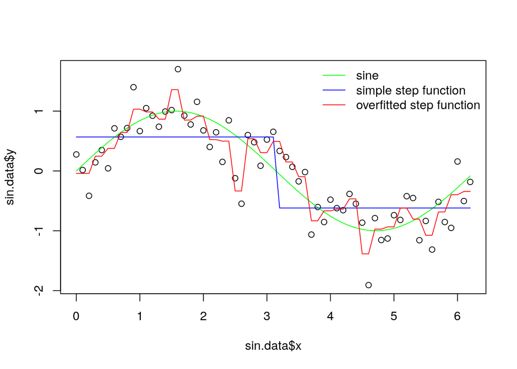

We have shown that a model with two **steps** underfits the data. A second option with approximately 30 steps does the opposite: each step’s estimate is based on only about two samples, which is too few. Ideally, each step should include 5–10 samples to reduce variance in the mean estimate, leading to models with roughly 6–12 steps. The exact optimal number can be determined using cross-validation.

## Summary

Let us compute the root mean square errors (RMSE) of all models in one place, starting with the **testing** (noisy) data. The first two lines report the performance of the baseline models: the least and the most informed. Note that there is an irreducible error in this data caused by noise as evident from the performance of the true sine model. The testing errors reported below should therefore be larger than this baseline. The **training errors** further illustrate the effect of overfitting: if they are substantially smaller than the testing errors, the model is overfitting the **training** data. Finally, we compute the RMSE of each model against the **ideal sine** function to assess how accurately they reconstruct the original signal.

RMSE of models for testing, training, and ideal sine data

| Model | Testing | Training | Ideal |
| --- | --- | --- | --- |
| zero benchmark | 0.8899 | 0.7650 | 0.7062 |
| true sine benchmark | 0.3850 | 0.3782 | 0.0000 |
| linear | 0.6265 | 0.5357 | 0.4455 |
| cubic polynomial | 0.3852 | 0.3615 | 0.1068 |
| 20th degree polynomial | 0.4201 | 0.2862 | 0.2473 |
| two steps | 0.5335 | 0.4825 | 0.3122 |
| 10 steps | 0.3979 | 0.3115 | 0.2286 |
| 50 steps | 0.4429 | 0.2441 | 0.2867 |
| linear spline with two knots | 0.3748 | 0.3562 | 0.1107 |
| quadratic spline with one knot | 0.3917 | 0.3719 | 0.0962 |
| cubic spline with one knot | 0.3851 | 0.3615 | 0.1067 |
| spline with 20 dfs | 0.4183 | 0.2869 | 0.2464 |
| smoothing spline with 4 dfs | 0.4133 | 0.3676 | 0.1527 |
| opt smoothing with 13.66 dfs | 0.3937 | 0.2983 | 0.1829 |

The quadratic spline with a single knot performed well in our scenario. This spline provided sufficient flexibility to fit the sine function without overfitting. The disadvantage is that we had to select the knot appropriately. The other simple non-linear functions, such as the degree-3 polynomial, cubic spline, and smoothing spline, also performed adequately. More complex models, however, tend to overfit the data. On the other hand, the degrees, steps or knot numbers have to be set high to see the overfitting effect at large. The amount of noise must also be considered when comparing models. Our default setting contains a relatively large amount of noise, which increases the risk of overfitting. If learning from less noisy data, more complex models could become advantageous.